# Overview

# II. Data Analysis

### 1. Vader Sentiment analysis

```python
# convert the csv file with review data into a new dataframe called "df_1" for further analysis
df_1=pd.read_csv('rotten_movie_review.csv')
```

```python
# display the 1st 5 rows of this new dataframe to ensure data looks good
df_1.head()
```

|  | Unnamed: 0 | User | Review |
| --- | --- | --- | --- |
| 0 | 0 | Adrienne | story dragged, cast believable many roles. especially disappointed angelina. |
| 1 | 1 | John B | sucked! way drawn out. eternals seemed like length movie! |
| 2 | 2 | Walls Family | movie drawn out, much action trailer made seem. kept going pst present got little confusing. good thought would be. son loves marvel movies said meh!. |
| 3 | 3 | Yousef H | excellent marvel cinematography! however many characters introduce short amount time, able properly build attachments characters way time movies climax would expect to. |
| 4 | 4 | scythe | people comments confused unsatisfied ignorance serves well. |

```python
# instantiate a SentimentIntensityAnalyzer object
analyzer = SentimentIntensityAnalyzer()
# The polarity_scores method of SentimentIntensityAnalyzer object returns a sentiment dictionary,which contains pos, neg, neu, and compound scores.
# The compound score is computed by normalizing the sum of positive,negative, and neutral scores
# and will be shown in normalized format whcih between -1(most negative) and 1 (most positive).
# Then store these ratings into different columns in df dataframe
df_1['compound'] = [analyzer.polarity_scores(x)['compound'] for x in df_1['Review']]
df_1['neg'] = [analyzer.polarity_scores(x)['neg'] for x in df_1['Review']]
df_1['neu'] = [analyzer.polarity_scores(x)['neu'] for x in df_1['Review']]
df_1['pos'] = [analyzer.polarity_scores(x)['pos'] for x in df_1['Review']]
# Create a new column to mark if the review is negative or positive based on resulted compound score.
# if compound score is >=0, then mark the review as "pos", else "neg"
df_1['Rating'] = df_1['compound'].apply(lambda x: 'pos'if x>=0 else 'neg')
```

```python
# to display the 1st 15 rows of this dataframe
df_1.head(15)
```

|  | Unnamed: 0 | User | Review | compound | neg | neu | pos | Rating |
| --- | --- | --- | --- | --- | --- | --- | --- | --- |
| 0 | 0 | Adrienne | story dragged, cast believable many roles. especially disappointed angelina. | -0.5563 | 0.396 | 0.604 | 0.000 | neg |
| 1 | 1 | John B | sucked! way drawn out. eternals seemed like length movie! | -0.2695 | 0.274 | 0.535 | 0.191 | neg |
| 2 | 2 | Walls Family | movie drawn out, much action trailer made seem. kept going pst present got little confusing. good thought would be. son loves marvel movies said meh!. | 0.8319 | 0.050 | 0.656 | 0.294 | pos |
| 3 | 3 | Yousef H | excellent marvel cinematography! however many characters introduce short amount time, able properly build attachments characters way time movies climax would expect to. | 0.8356 | 0.000 | 0.681 | 0.319 | pos |
| 4 | 4 | scythe | people comments confused unsatisfied ignorance serves well. | -0.6597 | 0.595 | 0.238 | 0.167 | neg |
| 5 | 5 | Ben | great, dont understand hate all. film introduces whats basically whole separate universe current marvel canon, fairly well. action pretty great, overall story. havent enjoyed marvel films recently qua… | 0.9099 | 0.151 | 0.502 | 0.347 | pos |
| 6 | 6 | Stephanie | honestly hype thought would love love avenger series marvel movies. however, many characters really get know feel connection them. me, movie lacks emotional connection. | 0.9413 | 0.000 | 0.546 | 0.454 | pos |
| 7 | 7 | DAMMIT360 | maybe shouldve committed like part part | 0.5574 | 0.000 | 0.465 | 0.535 | pos |
| 8 | 8 | MikeE A | shit. boring horrible story. bored explain more. watch this. dumb. | -0.9403 | 0.759 | 0.241 | 0.000 | neg |
| 9 | 9 | mm | excellent. dont forget two post credits end | 0.7824 | 0.000 | 0.337 | 0.663 | pos |
| 10 | 10 | J. Berman | i'm biggest marvel fan, movie took cake. one best movies seen recent years, music compelling beautiful. everything worked well tell story, all-star cast stole show. people movie critics reviewed back … | 0.9902 | 0.079 | 0.576 | 0.345 | pos |
| 11 | 11 | Vincent | disappointing long time marvel scifi fan. budget big good actors, movie much better. loses slow is. maybe different director could taken story knocked park. give second chance comes disney plus. | 0.7506 | 0.133 | 0.556 | 0.312 | pos |
| 12 | 12 | Bryce | honestly boring movie think ever seen almost feel asleep times could count found relieved use restroom could break minutes sit another horrendous hour movie. wasn’t even horrible freaking boring would… | -0.7351 | 0.287 | 0.547 | 0.166 | neg |
| 13 | 13 | Joseph | great story diversity cast. | 0.6249 | 0.000 | 0.423 | 0.577 | pos |
| 14 | 14 | Richard | really good movie. little slow developing action scenes well done movie ended better started | 0.8016 | 0.000 | 0.573 | 0.427 | pos |

```python
# to show the top 5 postive reviews
df_1.sort_values('compound', ascending=False).head(5)
```

|  | Unnamed: 0 | User | Review | compound | neg | neu | pos | Rating |
| --- | --- | --- | --- | --- | --- | --- | --- | --- |
| 1699 | 1699 | dre' S. | loved homage jack "the king" kirby creation 70's. see characters, last house ideas screen applied spin looking morality ikaris along unlikely deaths ajak gilgamesh took back mythology taught jack stan… | 0.9956 | 0.068 | 0.653 | 0.278 | pos |
| 1696 | 1696 | Ralph H | okay, i'm marvel fan. movie origin story going turn huge plot line going forward. yes, questions choices, overall amazing, acting better marvel movies, characters easy love, plot twists plenty, end cr… | 0.9940 | 0.025 | 0.369 | 0.607 | pos |
| 85 | 85 | Donna | fantastic! loved everything it! surprisingly funny! excellent storyline, fantastic action scenes, beautiful costumes, special effects, easy follow, characters well done! got thinking! loved laser acti… | 0.9913 | 0.000 | 0.353 | 0.647 | pos |
| 10 | 10 | J. Berman | i'm biggest marvel fan, movie took cake. one best movies seen recent years, music compelling beautiful. everything worked well tell story, all-star cast stole show. people movie critics reviewed back … | 0.9902 | 0.079 | 0.576 | 0.345 | pos |
| 1180 | 1180 | mike m | 3rd time seeing movie gets better every time watch it. loved marvel took risk movie completely paid different yes, still marvel movie yes, it’s popcorn kinda movie stunning special effects awesome set… | 0.9888 | 0.040 | 0.557 | 0.402 | pos |

```python
# to show the top 5 negative reviews
df_1.sort_values('compound', ascending=True).head(5)
```

|  | Unnamed: 0 | User | Review | compound | neg | neu | pos | Rating |
| --- | --- | --- | --- | --- | --- | --- | --- | --- |
| 1598 | 1598 | JDF | left movie halfway through. androgynous homo-sexual deities—socialist bs. also presented allied end war fascists tragic. conventional ground warfare carpet bombing killed multitudes a-bombs did. bad g… | -0.9702 | 0.505 | 0.439 | 0.056 | neg |
| 98 | 98 | luis | worst marvel movie date. many plot holes lot movie doesn’t make sense. lot feels forced. boring. really disappointed sad really sad | -0.9497 | 0.538 | 0.385 | 0.077 | neg |
| 8 | 8 | MikeE A | shit. boring horrible story. bored explain more. watch this. dumb. | -0.9403 | 0.759 | 0.241 | 0.000 | neg |
| 1527 | 1527 | Fernando U | disappointed movie. potential wasted. horrible character development, horrible accents, flat jokes poor storytelling. can’t believe green lighted is. | -0.9371 | 0.539 | 0.395 | 0.066 | neg |
| 297 | 297 | Adam | bad. bad writing bad lines. forced acting. chemistry among characters. | -0.9260 | 0.692 | 0.308 | 0.000 | neg |

```python
# to show descriptive statistics for the all numeric ratings
df_1.describe()
```

|  | Unnamed: 0 | compound | neg | neu | pos |
| --- | --- | --- | --- | --- | --- |
| count | 1990.000000 | 1990.000000 | 1990.000000 | 1990.000000 | 1990.000000 |
| mean | 994.500000 | 0.495589 | 0.088647 | 0.515641 | 0.395721 |
| std | 574.607837 | 0.465250 | 0.147242 | 0.203528 | 0.227262 |
| min | 0.000000 | -0.970200 | 0.000000 | 0.000000 | 0.000000 |
| 25% | 497.250000 | 0.273200 | 0.000000 | 0.378000 | 0.250250 |
| 50% | 994.500000 | 0.659700 | 0.000000 | 0.506000 | 0.398000 |
| 75% | 1491.750000 | 0.848400 | 0.142000 | 0.632000 | 0.559000 |
| max | 1989.000000 | 0.995600 | 0.844000 | 1.000000 | 1.000000 |

The mean compound score of the movie reviews is around 0.5 and only 25 percentile of the reviews score less than 0.27. This implies that most of the reviews are positive for this movie.

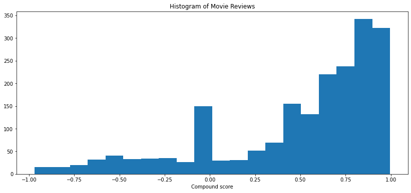

```python
# to plot the compound ratings in histagrams
plt.figure(figsize=(14,6))
plt.hist(df_1['compound'], bins=20)
plt.title('Histogram of Movie Reviews')
plt.xlabel('Compound score')
```

From the above bar charts, it demonstrates again that most of the reviews fall on positive range. And significant number of reviews are highly positive. It can also be observed that there is an outstanding peak for the number of neutral reviews compared to negative reviews which show a much more flat pattern through out the negative scoring range.

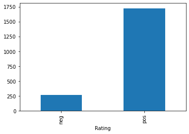

```python
# to group data by "Rating" column and show the size in bar chart
df_1.groupby('Rating').size().plot.bar()
```

Again, this bar chart demonstrates that the majority of the reviews are positive.

```python
# import python package for wordcloud
from wordcloud import WordCloud
```

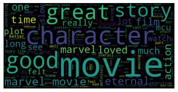

```python
# create wordcloud to show words that are frequently used in the reviews
wordcloud = WordCloud().generate(' '.join(df_1['Review']))
plt.imshow(wordcloud)
plt.axis("off")
plt.show()
```